# 6/30 Real data report

# 肺炎病患的住院天數(Y)之預測

- 因素考慮: 利用病人的**性別**、**年齡**、**體重**、**(7種)藥品使用的天數與總量**。
- 病患的住院天數:
1. 大於 30天住院天數的病患不考慮。判斷其住院天數並非主要由上方幾種因素控制，另外，從衛生福利部統計處網站上全民健康保險醫療統計年報，在肺炎疾病上平均住院日數統計最長 14.9天(103年)。 [衛生福利部統計處](https://dep.mohw.gov.tw/DOS/cp-1945-12042-113.html)
2. 小於 3天的病患，可能由於轉院或其它原因導致住院天數極短，亦不考慮。
- 註: 肺炎，由主診斷碼歸類(486、J188、J189、J150、J151)(?)
- 資料為**肺炎**與**住院天數介於4至30天**之病患，筆數為**2403**。

#### 資料清洗過程

0. 原始資料為102年~107年的xx醫院之病患住院紀錄: **71247**筆
1. 先將“住院迄日”為空白的刪除: 18023
2. 將“使用頻次”中有“XXX帶藥”的刪除: 4812
3. 將“使用頻次”中有“STAT”的刪除: 20505 共 71247 - 18023 - 4812 - 20505 = 27907 筆 以學長判斷肺炎: **6572**(是); 21335(否)
4. 將同一為病人且同一天住院(歸人)，判斷成一筆住院紀錄: **2747**筆
5. 考慮住院天數介於4至30天之病患: **2403**筆

# Two step 分析結果:

Mean Square Error (MSE): 21.5188 開根號後為 4.6388 天

- 性別: $\times$
- 年齡: $nonlinear$
- 體重: $\times$
- aminoglycosides: $nonlinear$
- carbapenems: $nonlinear$
- cephalosporins: $nonlinear$
- fluoroquinolones: $nonlinear$
- glycopeptide: $nonlinear$
- others: $nonlinear$
- penicillins: $nonlinear$

## 1.性別: $\times$

假設檢定: 男生與女生之住院天數是否有差別

95 percent confidence interval: [ 0.8278724 , 2.0290919 ]

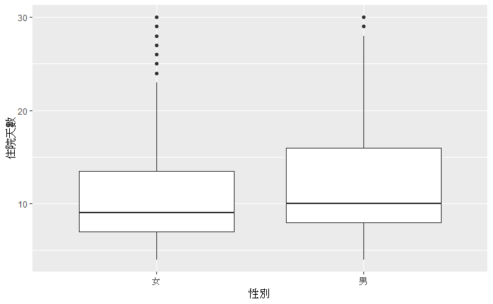

```
    Welch Two Sample t-test

data:  data %>% filter(性別 == "男") %>% select(住院天數) and data %>% filter(性別 == 女") %>% select(住院天數)
t = 4.6678, df = 911.35, p-value = 3.502e-06
alternative hypothesis: true difference in means is not equal to 0
95 percent confidence interval:
 0.8278724 2.0290919
sample estimates:
mean of x mean of y
 12.34562  10.91714
```

## 2.年齡: $nonlinear$

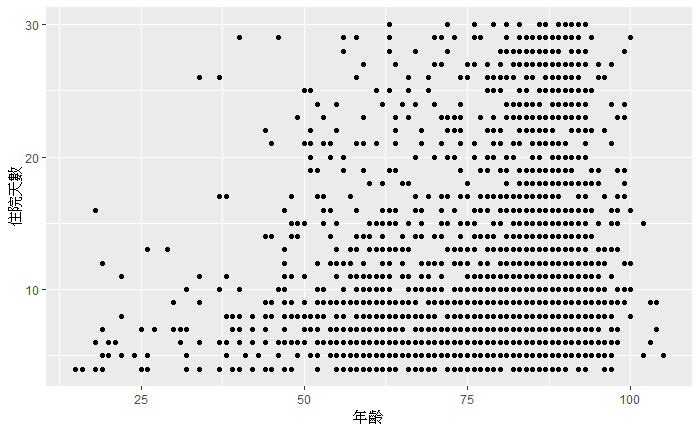

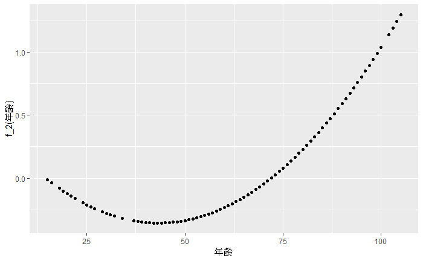

## 3.體重: $\times$

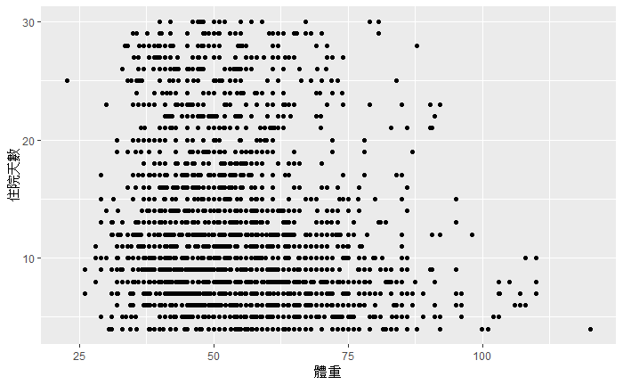

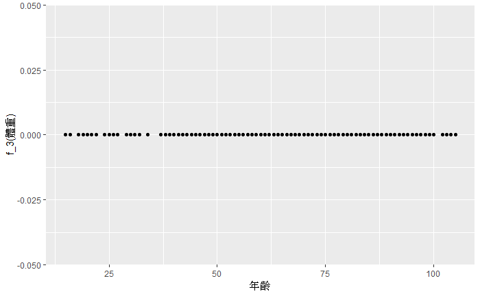

## 4.aminoglycosides: $nonlinear$

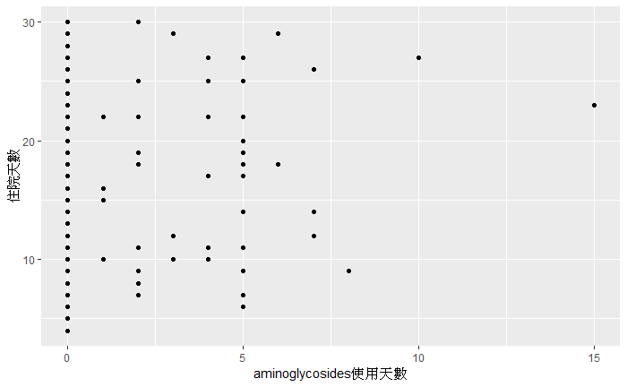

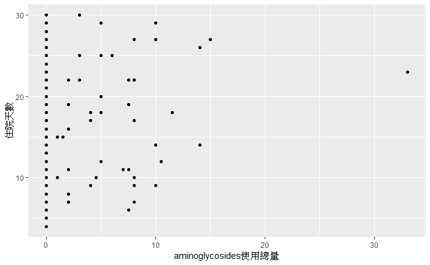

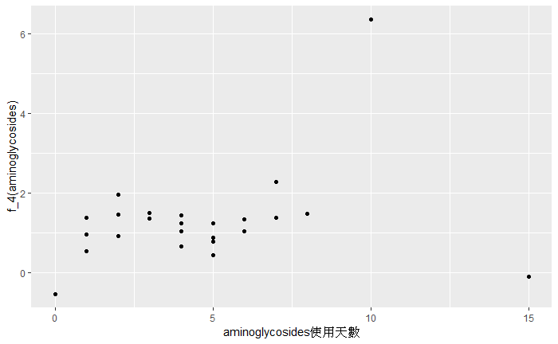

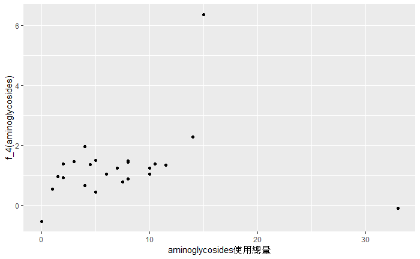

## 5.carbapenems: $nonlinear$

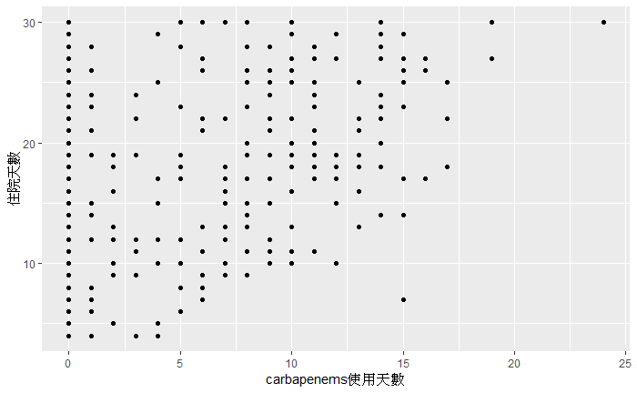

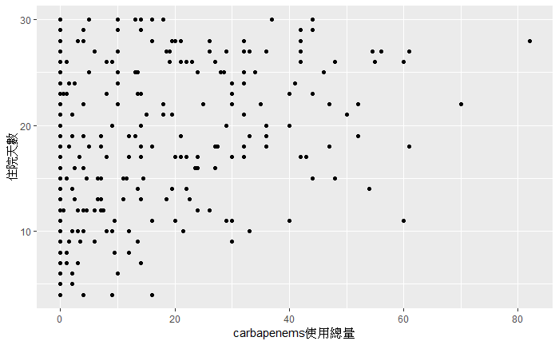

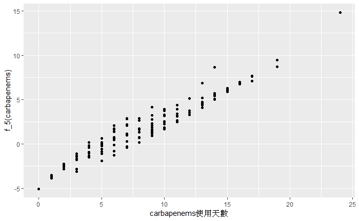

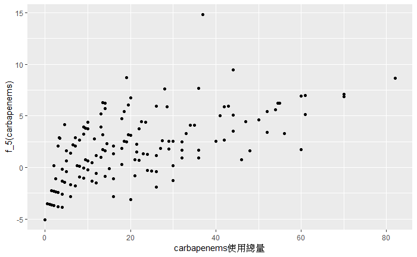

## 6.cephalosporins: $nonlinear$

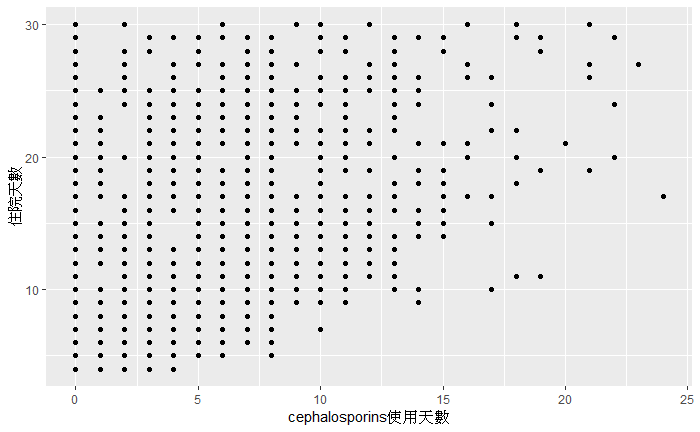

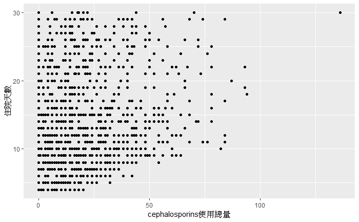

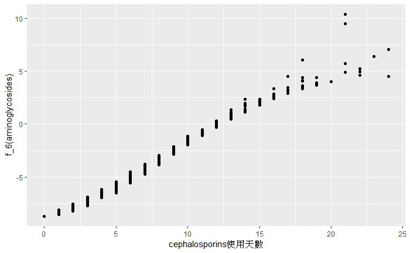

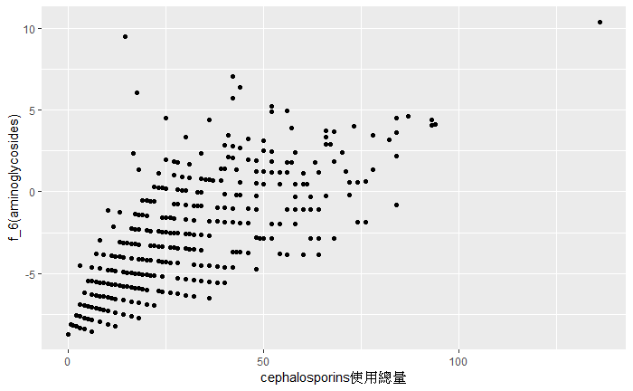

## 7.fluoroquinolones: $nonlinear$

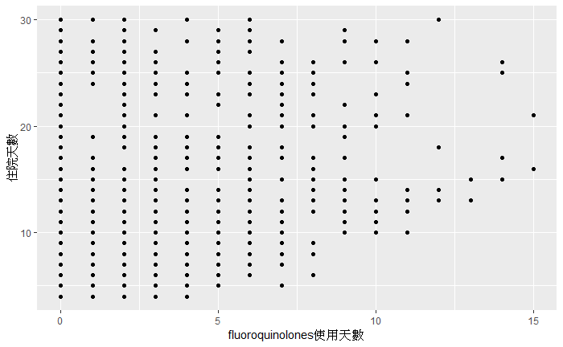

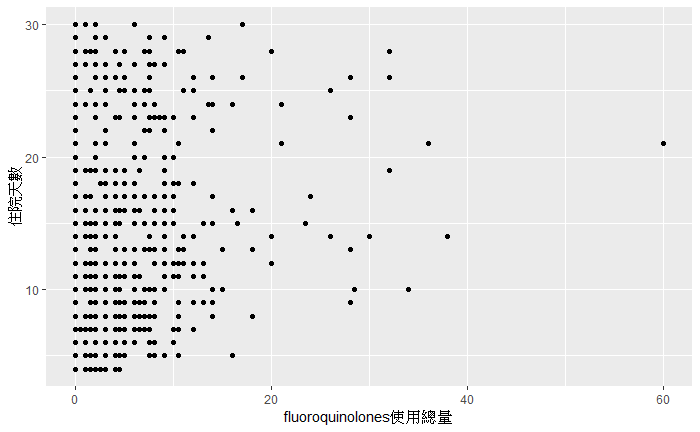

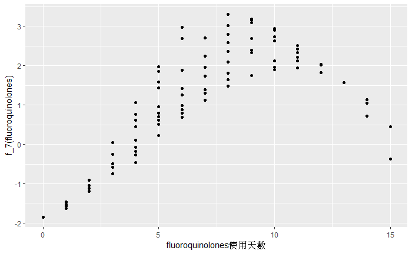

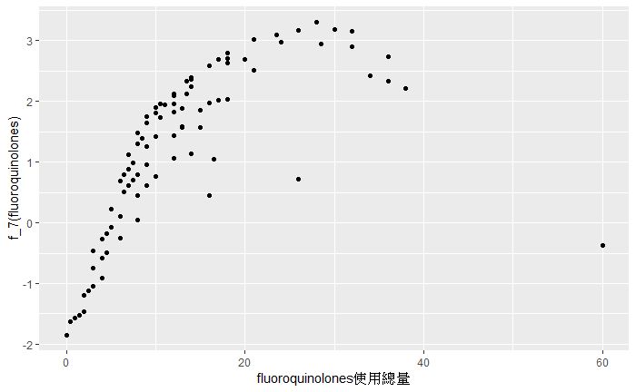

## 8.glycopeptide: $nonlinear$

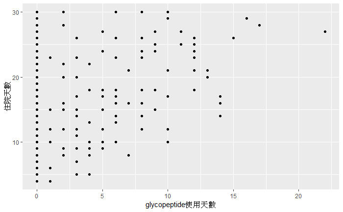

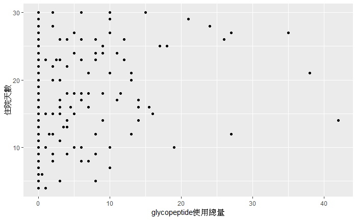

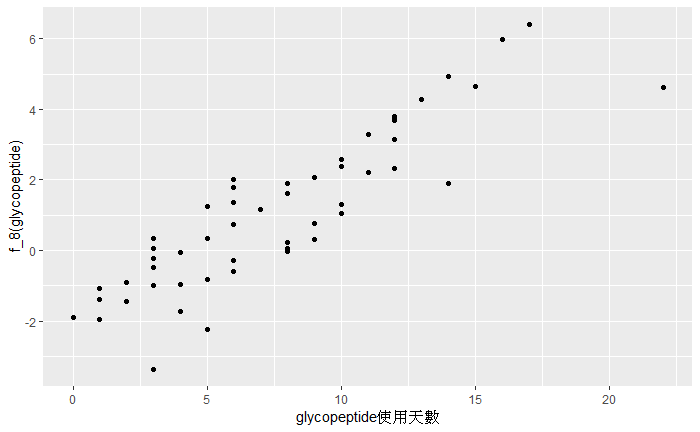

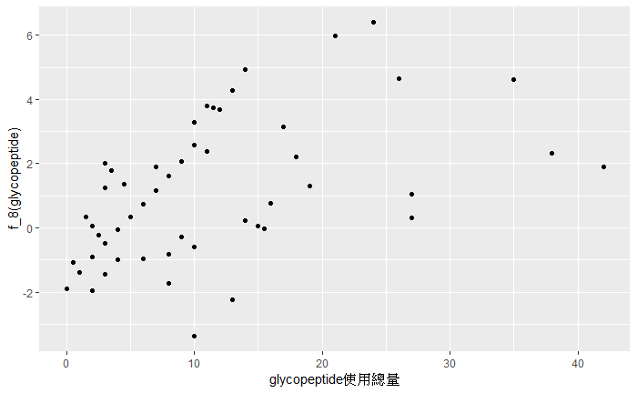

## 9.others: $nonlinear$

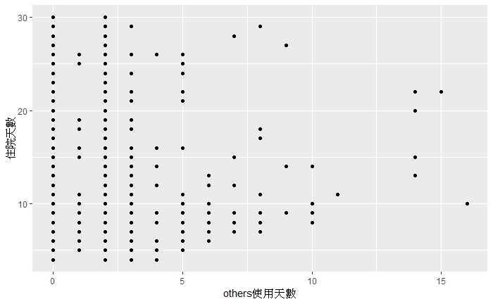

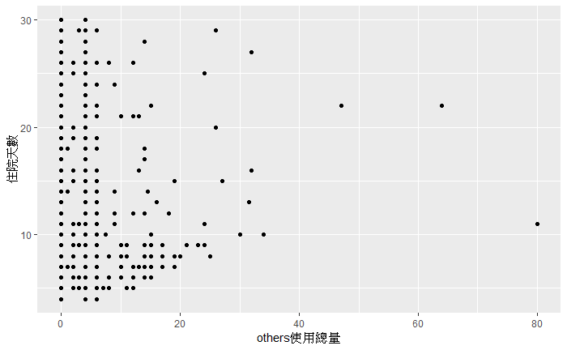

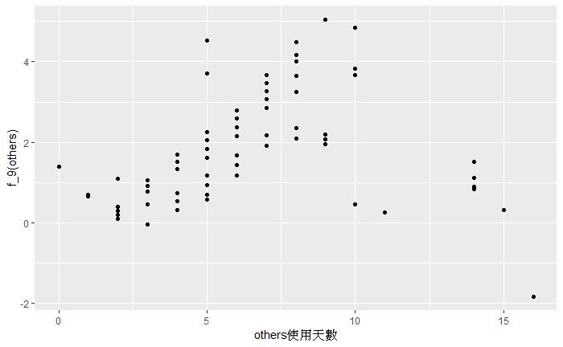

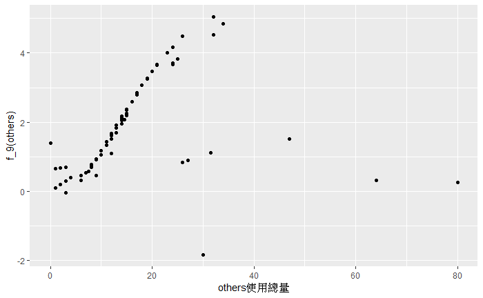